# Descriptive tables and figures

Exact-layout replication with updated verified data and documented corrections

Last modified:

August 1, 2026

## Scope and result

This document reproduces the submitted table styles, figure compositions, and manuscript-scale canvases from the earlier manuscript-generating descriptive analysis, but fills them with the updated verified data. It also repairs errors that could not responsibly be copied forward. The main analytical measurement is near-eye melEDI; chest measurement is shown only as a complementary description and the two placements are never pooled.

The replicated layouts include the wide participant-and-site table, the wide site-by-metric table with miniature distributions, the five-part study overview, the 3 × 3 site profiles, the 4 × 4 metric grid, the four-panel time-series explanation, the latitude–photoperiod diagnostic, and the site-by-state light-context table.

All 12 required shared manifests matched their pinned SHA-256 fingerprints before any analytical input was read. The current display registry is `config/site_display_registry.csv`; it supplies the labels, visible order, and colours in every table and figure. The visible site sequence is Borås (SE), Delft (NL), Dortmund (DE), Tübingen (DE), Munich (DE), Madrid (ES), Izmir (TR), San José (CR), Kumasi (GH).

## Updated sample

The normalized participant roster contains **191 participants**. After the pre-specified ≥80% full-day completeness rule and exact-all-zero screen, the main near-eye dataset contains **141 participants, 816 participant-days, and 1,175,160 one-minute real observations**. The complementary chest dataset contains **154 participants, 902 participant-days, and 1,298,880 one-minute real observations**. The paired subset contains **112 participants and 643 participant-days**.

Two of 818 otherwise eligible near-eye participant-days and three of 905 otherwise eligible chest participant-days were exact-all-zero melEDI days and were excluded. A participant was not removed merely because one of their days was excluded.

Table 1: Updated descriptive sample after each fixed coverage step.

| Stage | Placement | Participants | Participant-days | One-minute real observations |
| --- | --- | --- | --- | --- |
| Available normalized participant metadata | participant roster | 191 | Not applicable | Not applicable |
| At least 80% complete before all-zero screen | near_eye | Not applicable | 818 | Not applicable |
| Exact all-zero days excluded | near_eye | Not applicable | 2 | Not applicable |
| Main dataset after all-zero screen | near_eye | 141 | 816 | 1,175,160 |
| At least 80% complete before all-zero screen | chest | Not applicable | 905 | Not applicable |
| Exact all-zero days excluded | chest | Not applicable | 3 | Not applicable |
| Main dataset after all-zero screen | chest | 154 | 902 | 1,298,880 |
| Paired main subset | paired | 112 | 643 | Not applicable |

## Table 1: participant and site characteristics

Table 2 keeps the earlier wide site-column organization. Cells now identify whether a quantity belongs to near-eye, chest, paired, roster, or diary data. Participant information covers the complete normalized roster. Collection dates and civil photoperiod use the union of every recorded non-all-zero participant-day across both placements; screened-day counts retain the main-analysis completeness rule.

Table 2: Participant, site, collection, sleep, chronotype, and wear characteristics using updated verified data.

|  | Overall | Borås (SE) | Delft (NL) | Dortmund (DE) | Tübingen (DE) | Munich (DE) | Madrid (ES) | Izmir (TR) | San José (CR) | Kumasi (GH) |
| --- | --- | --- | --- | --- | --- | --- | --- | --- | --- | --- |
| Site specifics |  |  |  |  |  |  |  |  |  |  |
| Institution | Overall | RISE | THUAS | BAUA | MPI | TUM | FUSPCEU | IZTECH | UCR | KNUST |
| Country | — | Sweden | Netherlands | Germany | Germany | Germany | Spain | Türkiye | Costa Rica | Ghana |
| City | — | Borås | Delft | Dortmund | Tübingen | Munich | Madrid | Izmir | San José | Kumasi |
| Coordinates | — | 57.7°N, 12.9°E | 52.0°N, 4.4°E | 51.5°N, 7.4°E | 48.5°N, 9.1°E | 48.1°N, 11.6°E | 40.4°N, 3.7°W | 38.3°N, 26.6°E | 9.9°N, 84.1°W | 6.7°N, 1.6°W |
| Data collection |  |  |  |  |  |  |  |  |  |  |
| Participants<sup>1</sup> | 191 roster (**g:143**; c:157; p:116) | 17 roster (**g:14**; c:17; p:14) | 20 roster (**g:13**; c:15; p:13) | 24 roster (**g:19**; c:22; p:19) | 26 roster (**g:26**; c:0; p:0) | 10 roster (**g:10**; c:10; p:10) | 23 roster (**g:23**; c:22; p:22) | 17 roster (**g:17**; c:17; p:17) | 39 roster (**g:6**; c:39; p:6) | 15 roster (**g:15**; c:15; p:15) |
| Participant-days<sup>1</sup> | 1478 roster (g:1134 c:1246; p:902) | 137 roster (g:107 c:137; p:107) | 125 roster (g:107 c:124; p:106) | 176 roster (g:145 c:163; p:132) | 208 roster (g:208 c:0; p:0) | 80 roster (g:80 c:80; p:80) | 182 roster (g:182 c:174; p:174) | 138 roster (g:138 c:138; p:138) | 312 roster (g:48 c:312; p:48) | 120 roster (g:119 c:118; p:117) |
| Weekday / weekend | **g:850 / 284** c:935 / 311 | **g:81 / 26** c:103 / 34 | **g:79 / 28** c:93 / 31 | **g:109 / 36** c:123 / 40 | **g:156 / 52** c:0 / 0 | **g:60 / 20** c:60 / 20 | **g:136 / 46** c:130 / 44 | **g:104 / 34** c:104 / 34 | **g:36 / 12** c:233 / 79 | **g:89 / 30** c:89 / 29 |
| Workday / free-day diaries | 824 work / 451 free (n=1275 diaries) | 77 work / 40 free (n=117 diaries) | 70 work / 31 free (n=101 diaries) | 95 work / 54 free (n=149 diaries) | 115 work / 66 free (n=181 diaries) | 38 work / 32 free (n=70 diaries) | 95 work / 54 free (n=149 diaries) | 99 work / 38 free (n=137 diaries) | 180 work / 87 free (n=267 diaries) | 55 work / 49 free (n=104 diaries) |
| Participant time<sup>2</sup> | 116w 4d | 11w 23h | 11w 23h | 15w 2d | 21w 3d | 8w 4d | 18w 3d | 14w 3d | 4w 4d | 11w 4d |
| Declared non-wear<sup>2</sup> | **g:4w 1d (3.66%)** | **g:2d 14h (3.34%)** | **g:3d 1h (3.92%)** | **g:3d 15h (3.42%)** | **g:6d 10h (4.30%)** | **g:2d 17h (4.55%)** | **g:2d 20h (2.20%)** | **g:3d 3h (3.13%)** | **g:1d 11h (4.66%)** | **g:3d 21h (4.80%)** |
| Screened days<sup>1,3</sup> | **g:816** c:902 | **g:78** c:96 | **g:78** c:93 | **g:107** c:114 | **g:150** c:0 | **g:60** c:60 | **g:129** c:123 | **g:101** c:102 | **g:32** c:230 | **g:81** c:84 |
| Collection dates<sup>4</sup> | 23/08/14–25/10/20 (n=1478 d) | 25/03/03–25/10/20 (n=137 d) | 25/02/21–25/10/14 (n=125 d) | 25/06/10–25/10/20 (n=176 d) | 23/08/14–23/11/13 (n=208 d) | 24/05/13–24/07/29 (n=80 d) | 24/10/07–25/02/10 (n=182 d) | 24/12/23–25/06/02 (n=138 d) | 25/06/16–25/09/07 (n=312 d) | 24/10/07–25/02/03 (n=120 d) |
| Civil photoperiod<sup>5,2</sup> | 13.25 h (10.62–18.20) (n=1478 d) | 14.81 h (11.80–20.49) (n=137 d) | 14.00 h (11.88–18.09) (n=125 d) | 17.88 h (11.76–18.22) (n=176 d) | 12.07 h (10.55–15.41) (n=208 d) | 17.20 h (16.45–17.45) (n=80 d) | 11.01 h (10.35–12.22) (n=182 d) | 13.13 h (10.52–15.57) (n=138 d) | 13.34 h (13.01–13.47) (n=312 d) | 12.54 h (12.49–12.68) (n=120 d) |
| Participant information |  |  |  |  |  |  |  |  |  |  |
| Age<sup>5</sup> | 28 y (21 y–52 y) (n=191 N) | 38 y (22.6 y–64.8 y) (n=17 N) | 30.5 y (19.9 y–57.1 y) (n=20 N) | 35.5 y (20.1 y–58.5 y) (n=24 N) | 27 y (22 y–37 y) (n=26 N) | 27.5 y (22.2 y–29 y) (n=10 N) | 31 y (20.2 y–54.3 y) (n=23 N) | 24 y (21 y–29.6 y) (n=17 N) | 34 y (22 y–48.1 y) (n=39 N) | 23 y (20.1 y–25 y) (n=15 N) |
| Sex<sup>6</sup> | F:105 / M:86 (n=191) | F:6 / M:11 (n=17) | F:8 / M:12 (n=20) | F:13 / M:11 (n=24) | F:14 / M:12 (n=26) | F:6 / M:4 (n=10) | F:15 / M:8 (n=23) | F:11 / M:6 (n=17) | F:24 / M:15 (n=39) | F:8 / M:7 (n=15) |
| Gender<sup>6</sup> | W:106 / M:84 / NB:1 (n=191) | W:6 / M:11 / NB:0 (n=17) | W:9 / M:10 / NB:1 (n=20) | W:13 / M:11 / NB:0 (n=24) | W:14 / M:12 / NB:0 (n=26) | W:6 / M:4 / NB:0 (n=10) | W:15 / M:8 / NB:0 (n=23) | W:11 / M:6 / NB:0 (n=17) | W:24 / M:15 / NB:0 (n=39) | W:8 / M:7 / NB:0 (n=15) |
| Employment status<sup>7</sup> | F:163 / P:26 / N:2 (n=191) | F:16 / P:0 / N:1 (n=17) | F:11 / P:9 / N:0 (n=20) | F:21 / P:3 / N:0 (n=24) | F:23 / P:3 / N:0 (n=26) | F:9 / P:1 / N:0 (n=10) | F:21 / P:2 / N:0 (n=23) | F:15 / P:2 / N:0 (n=17) | F:34 / P:5 / N:0 (n=39) | F:13 / P:1 / N:1 (n=15) |
| Chronotype group<sup>8</sup> | m:62 / i:94 / e:30 (n=186) | m:8 / i:4 / e:5 (n=17) | m:3 / i:9 / e:3 (n=15) | m:8 / i:13 / e:3 (n=24) | m:9 / i:9 / e:8 (n=26) | m:0 / i:8 / e:2 (n=10) | m:5 / i:17 / e:1 (n=23) | m:2 / i:10 / e:5 (n=17) | m:16 / i:20 / e:3 (n=39) | m:11 / i:4 / e:0 (n=15) |
| Sleep-corrected midsleep on free days<sup>5,9</sup> | 04:03 (02:08–06:15) (n=185 N) | 02:55 (02:04–05:09) (n=17 N) | 04:31 (03:05–05:37) (n=15 N) | 03:47 (02:17–04:49) (n=24 N) | 04:33 (02:41–06:04) (n=26 N) | 05:08 (04:12–06:04) (n=10 N) | 04:48 (03:10–06:52) (n=22 N) | 05:29 (03:35–06:49) (n=17 N) | 03:42 (02:17–05:31) (n=39 N) | 02:19 (01:22–03:25) (n=15 N) |
| Morningness–Eveningness Questionnaire score<sup>5,9</sup> | 54 (35–69.8) (n=186 N) | 58 (34–71.4) (n=17 N) | 49 (38.4–61.3) (n=15 N) | 51.5 (40.1–70.2) (n=24 N) | 49 (33–68.2) (n=26 N) | 44.5 (37.7–57.5) (n=10 N) | 52 (42–66.8) (n=23 N) | 52 (31.6–60.4) (n=17 N) | 58 (40.5–69.2) (n=39 N) | 62 (50.6–72.3) (n=15 N) |
| Social jetlag<sup>5,2</sup> | 1 h (0 h–2.75 h) (n=185 N) | 0.625 h (-0.0167 h–3.08 h) (n=17 N) | 0.75 h (0.0875 h–1.82 h) (n=15 N) | 1.27 h (0.5 h–2.16 h) (n=24 N) | 0.896 h (0 h–1.85 h) (n=26 N) | 0.938 h (0.5 h–2.41 h) (n=10 N) | 1.38 h (0.0683 h–3.31 h) (n=22 N) | 1.08 h (0.333 h–2.04 h) (n=17 N) | 1.08 h (0 h–2.6 h) (n=39 N) | 0.25 h (0 h–1.3 h) (n=15 N) |
| Sleep duration<sup>5,2</sup> | 7.58 h (5.16–10.27) (n=1275 diaries / 184 N) | 7.42 h (5.65–9.74) (n=117 diaries / 17 N) | 7.88 h (5.75–10.00) (n=101 diaries / 15 N) | 7.92 h (5.67–10.28) (n=149 diaries / 22 N) | 7.43 h (4.52–9.25) (n=181 diaries / 26 N) | 7.80 h (5.00–10.77) (n=70 diaries / 10 N) | 7.82 h (5.87–11.67) (n=149 diaries / 23 N) | 7.83 h (4.73–11.07) (n=137 diaries / 17 N) | 7.08 h (5.08–9.30) (n=267 diaries / 39 N) | 7.62 h (5.01–10.73) (n=104 diaries / 15 N) |

<sup>1</sup> Near-eye is the primary placement; chest is complementary; paired means the same participant-day is available at both placements.  
<sup>2</sup> w: weeks; d: days; h: hours; min: minutes. Participant time and declared non-wear use eligible real minutes on screened days; both are shown for near-eye only.  
<sup>3</sup> Screened days are the final participant-days after the 80% completeness screen and exclusion of exact-all-zero melEDI days.  
<sup>4</sup> Minimum–maximum local-date span across the available roster.  
<sup>5</sup> Median (5th percentile, 95th percentile).  
<sup>6</sup> Sex categories: Female and Male; gender categories: Woman, Man, and Non-binary.  
<sup>7</sup> Employment categories reproduce the submitted grouping: Full/studying, Part/marginal, and Not employed.  
<sup>8</sup> Chronotype groups follow the Morningness–Eveningness Questionnaire score.  
<sup>9</sup> MCTQ: Munich Chronotype Questionnaire; MEQ: Morningness–Eveningness Questionnaire. Clock summaries are circular.

Important corrections embodied in Table 2 are:

- MPI is displayed as Tübingen and TUM as Munich, repairing their interchanged institution labels in the earlier table.
- Participant and participant-day rows show the whole available roster plus near-eye, chest, and paired subsets. Participant time retains the screened near-eye basis and is limited to its two largest time units.
- Declared non-wear is reported for near-eye only; the earlier chest display reused the near-eye input and has therefore been removed.
- Screened days show only the final result after the completeness and all-zero screens. Civil photoperiod comes from verified site-and-solar context across the whole available roster.
- Clock-time chronotype summaries are circular. During rebuilding, a `quantile()` argument typo in the first implementation was detected, documented, and corrected before this final table was generated.

## Table 2: metric distributions

Table 3 reproduces the old metric categories, order, ten site columns, scaling column, and enlarged miniature distribution column. Every numerical cell states `N`, the number of participants, and `d`, the number of participant-days with a finite value. The site columns have equal widths and each median, interval, mean ± SD, and size line is kept intact.

Table 3: Near-eye melEDI metric distributions overall and by site using updated verified metric artifacts.

Metric descriptive summary (near-eye)

Unit

Overall

Borås (SE)

Delft (NL)

Dortmund (DE)

Tübingen (DE)

Munich (DE)

Madrid (ES)

Izmir (TR)

San José (CR)

Kumasi (GH)

Scaling<sup>1</sup>

Distribution<sup>2</sup>

Duration

Time above 1,000 lx melEDI

HH:MM

**00:41**  
(00:11, 01:34)  
*01:10 ± 01:28*  
N=141; d=816

**01:18**  
(00:31, 03:24)  
*02:00 ± 01:54*  
N=13; d=78

**01:18**  
(00:29, 02:12)  
*01:33 ± 01:28*  
N=13; d=78

**01:03**  
(00:20, 02:32)  
*01:48 ± 02:14*  
N=18; d=107

**00:40**  
(00:07, 01:25)  
*01:06 ± 01:22*  
N=26; d=150

**00:39**  
(00:10, 01:46)  
*01:09 ± 01:18*  
N=10; d=60

**00:27**  
(00:06, 00:53)  
*00:38 ± 00:47*  
N=23; d=129

**00:30**  
(00:06, 01:04)  
*00:44 ± 00:51*  
N=17; d=101

**00:19**  
(00:09, 00:43)  
*00:32 ± 00:33*  
N=6; d=32

**00:43**  
(00:17, 01:14)  
*00:58 ± 00:57*  
N=15; d=81

Log 10 zero inflated

Time above 1,000 lx melEDI distribution by site. Exact numerical summaries are in the adjacent cells.

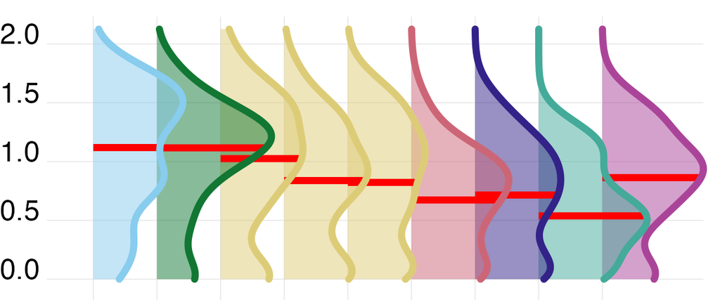

Time above 250 lx melEDI during wake

HH:MM

**02:25**  
(00:51, 04:37)  
*03:00 ± 02:29*  
N=141; d=737

**04:06**  
(02:30, 06:15)  
*04:21 ± 02:24*  
N=13; d=73

**03:29**  
(02:03, 05:16)  
*03:39 ± 02:25*  
N=13; d=64

**03:42**  
(02:05, 05:58)  
*04:05 ± 02:51*  
N=18; d=90

**02:01**  
(00:47, 04:20)  
*02:52 ± 02:39*  
N=26; d=141

**02:38**  
(00:55, 04:19)  
*02:57 ± 02:19*  
N=10; d=54

**02:43**  
(00:54, 04:43)  
*03:02 ± 02:19*  
N=23; d=113

**01:30**  
(00:41, 03:26)  
*02:09 ± 01:57*  
N=17; d=94

**01:39**  
(00:33, 02:40)  
*01:48 ± 01:21*  
N=6; d=30

**01:14**  
(00:25, 02:37)  
*01:45 ± 01:46*  
N=15; d=78

Log 10 zero inflated

Time above 250 lx melEDI during wake distribution by site. Exact numerical summaries are in the adjacent cells.

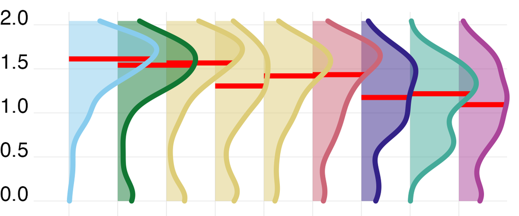

Time below 10 lx melEDI before sleep

HH:MM

**01:53**  
(01:01, 02:35)  
*01:51 ± 01:02*  
N=139; d=655

**02:16**  
(01:30, 02:39)  
*02:05 ± 00:53*  
N=13; d=67

**01:50**  
(01:21, 02:52)  
*01:59 ± 00:57*  
N=12; d=50

**01:42**  
(00:53, 02:17)  
*01:41 ± 00:58*  
N=18; d=84

**01:52**  
(01:04, 02:25)  
*01:52 ± 01:06*  
N=26; d=132

**01:43**  
(00:42, 02:32)  
*01:45 ± 01:10*  
N=10; d=52

**01:43**  
(00:58, 02:50)  
*01:50 ± 01:05*  
N=23; d=105

**01:31**  
(00:49, 02:15)  
*01:38 ± 01:00*  
N=17; d=82

**02:16**  
(01:15, 02:39)  
*01:56 ± 01:00*  
N=6; d=25

**02:30**  
(01:28, 02:52)  
*02:09 ± 00:57*  
N=14; d=58

Log 10 zero inflated

Time below 10 lx melEDI before sleep distribution by site. Exact numerical summaries are in the adjacent cells.

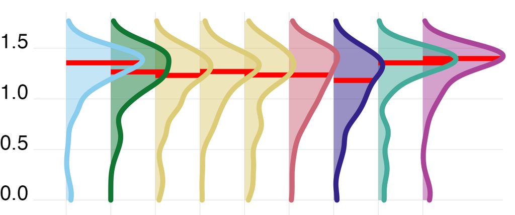

Time below 1 lx melEDI during sleep

HH:MM

**07:08**  
(05:58, 08:15)  
*07:04 ± 01:57*  
N=141; d=778

**07:08**  
(06:03, 08:18)  
*07:12 ± 01:46*  
N=13; d=76

**07:14**  
(05:56, 08:06)  
*07:01 ± 01:50*  
N=13; d=68

**07:08**  
(05:56, 08:16)  
*07:05 ± 01:50*  
N=18; d=95

**06:54**  
(05:51, 07:46)  
*06:47 ± 01:30*  
N=26; d=150

**05:52**  
(04:41, 07:03)  
*05:58 ± 01:58*  
N=10; d=60

**08:06**  
(07:10, 09:10)  
*08:02 ± 01:57*  
N=23; d=118

**06:45**  
(05:08, 08:15)  
*06:40 ± 02:07*  
N=17; d=99

**06:56**  
(06:06, 07:36)  
*06:39 ± 01:43*  
N=6; d=31

**07:31**  
(06:31, 09:00)  
*07:35 ± 02:15*  
N=15; d=81

Log 10 zero inflated

Time below 1 lx melEDI during sleep distribution by site. Exact numerical summaries are in the adjacent cells.

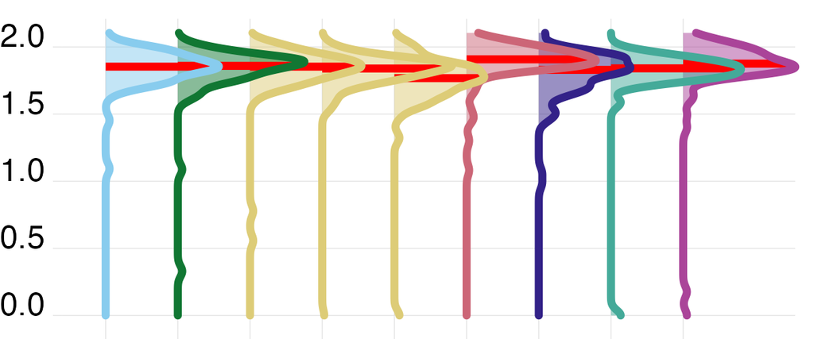

Longest period above 250 lx melEDI

HH:MM

**00:38**  
(00:17, 01:12)  
*00:55 ± 01:00*  
N=141; d=816

**00:56**  
(00:28, 01:27)  
*01:12 ± 01:02*  
N=13; d=78

**00:48**  
(00:23, 01:20)  
*01:09 ± 01:15*  
N=13; d=78

**01:00**  
(00:21, 01:40)  
*01:20 ± 01:31*  
N=18; d=107

**00:35**  
(00:13, 01:06)  
*00:50 ± 00:54*  
N=26; d=150

**00:38**  
(00:17, 01:32)  
*01:01 ± 01:02*  
N=10; d=60

**00:38**  
(00:16, 01:04)  
*00:45 ± 00:36*  
N=23; d=129

**00:34**  
(00:14, 00:55)  
*00:43 ± 00:41*  
N=17; d=101

**00:28**  
(00:16, 00:43)  
*00:30 ± 00:20*  
N=6; d=32

**00:23**  
(00:15, 00:49)  
*00:38 ± 00:45*  
N=15; d=81

Log 10 zero inflated

Longest period above 250 lx melEDI distribution by site. Exact numerical summaries are in the adjacent cells.

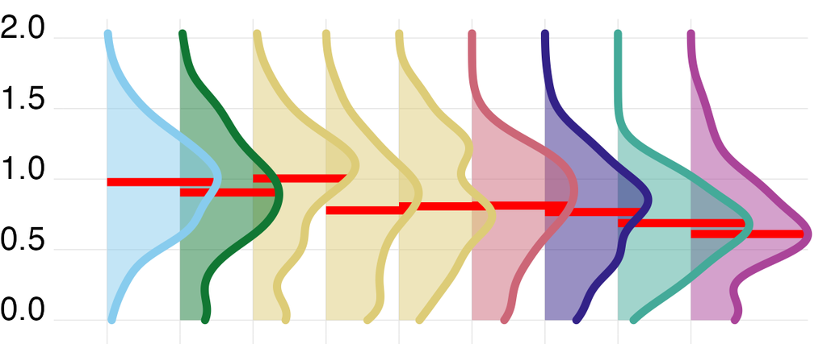

Dynamics

Interdaily stability

dimensionless

**0.308**  
(0.248, 0.38)  
*0.318 ± 0.0949*  
N=141; d=816

**0.311**  
(0.272, 0.367)  
*0.315 ± 0.0775*  
N=13; d=78

**0.258**  
(0.239, 0.389)  
*0.288 ± 0.0939*  
N=13; d=78

**0.264**  
(0.219, 0.319)  
*0.274 ± 0.074*  
N=18; d=107

**0.329**  
(0.263, 0.424)  
*0.344 ± 0.107*  
N=26; d=150

**0.244**  
(0.218, 0.277)  
*0.252 ± 0.0581*  
N=10; d=60

**0.352**  
(0.321, 0.455)  
*0.368 ± 0.0921*  
N=23; d=129

**0.278**  
(0.254, 0.394)  
*0.323 ± 0.104*  
N=17; d=101

**0.342**  
(0.315, 0.473)  
*0.37 ± 0.118*  
N=6; d=32

**0.293**  
(0.255, 0.354)  
*0.299 ± 0.0625*  
N=15; d=81

Identity

Interdaily stability distribution by site. Exact numerical summaries are in the adjacent cells.

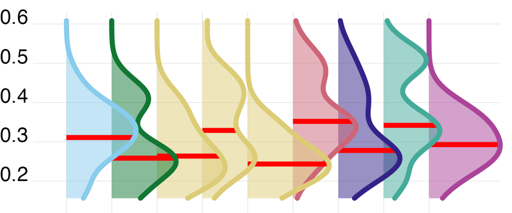

Intradaily variability

dimensionless

**1.25**  
(0.93, 1.5)  
*1.23 ± 0.389*  
N=141; d=816

**0.997**  
(0.818, 1.39)  
*1.09 ± 0.343*  
N=13; d=78

**1.19**  
(0.96, 1.39)  
*1.24 ± 0.345*  
N=13; d=78

**1.18**  
(0.928, 1.49)  
*1.18 ± 0.407*  
N=18; d=107

**1.15**  
(0.801, 1.44)  
*1.13 ± 0.354*  
N=26; d=150

**1.48**  
(0.869, 1.64)  
*1.33 ± 0.477*  
N=10; d=60

**1.25**  
(0.999, 1.5)  
*1.25 ± 0.413*  
N=23; d=129

**1.36**  
(0.95, 1.55)  
*1.31 ± 0.415*  
N=17; d=101

**1.4**  
(1.28, 1.48)  
*1.36 ± 0.256*  
N=6; d=32

**1.32**  
(1.03, 1.59)  
*1.34 ± 0.413*  
N=15; d=81

Identity

Intradaily variability distribution by site. Exact numerical summaries are in the adjacent cells.

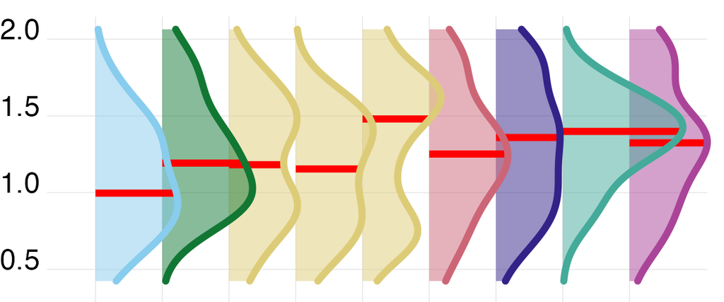

Exposure history

melEDI dose

klx·h

**4.96**  
(1.94, 12.3)  
*10.4 ± 16.2*  
N=141; d=761

**9.3**  
(3.89, 21.9)  
*19.9 ± 27.8*  
N=13; d=71

**10.5**  
(3.85, 17.4)  
*15.9 ± 20.4*  
N=13; d=74

**6.75**  
(2.47, 14.4)  
*13.8 ± 23.7*  
N=18; d=97

**3.86**  
(1.41, 10.2)  
*7.72 ± 9.85*  
N=26; d=137

**7.11**  
(1.9, 15.8)  
*10.1 ± 11.2*  
N=10; d=55

**3.32**  
(1.7, 6.29)  
*6.11 ± 8.79*  
N=23; d=125

**4.35**  
(1.79, 10.6)  
*7.49 ± 8.9*  
N=17; d=96

**2.2**  
(1.34, 4.12)  
*3.28 ± 2.57*  
N=6; d=30

**6.04**  
(2.49, 14.9)  
*10 ± 10.8*  
N=15; d=76

Log 10 zero inflated

melEDI dose distribution by site. Exact numerical summaries are in the adjacent cells.

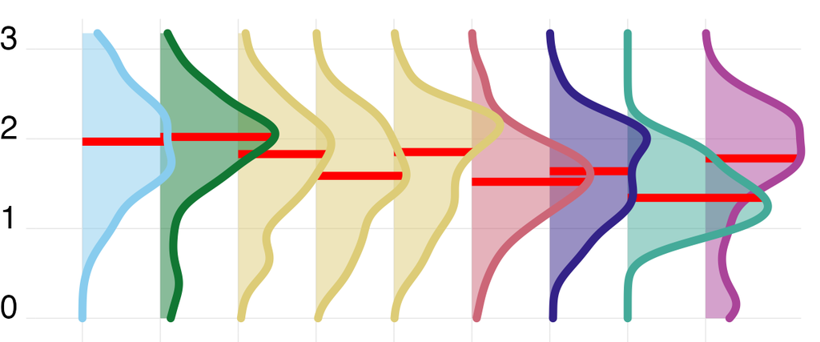

Level

Mean melEDI

lx

**5.154**  
(2.831, 9.225)  
*7.587 ± 9.496*  
N=141; d=816

**7.569**  
(4.55, 11.61)  
*9.171 ± 7.111*  
N=13; d=78

**6.659**  
(4.18, 11.67)  
*8.274 ± 6.558*  
N=13; d=78

**7.704**  
(3.081, 13.92)  
*12.02 ± 18.86*  
N=18; d=107

**5.232**  
(3.224, 8.188)  
*7.221 ± 6.33*  
N=26; d=150

**9.013**  
(4.011, 15.09)  
*12.1 ± 12.01*  
N=10; d=60

**3.505**  
(1.469, 6.211)  
*4.166 ± 3.272*  
N=23; d=129

**5.857**  
(3.726, 7.986)  
*7.778 ± 6.946*  
N=17; d=101

**4.325**  
(3.585, 6.77)  
*5.248 ± 2.85*  
N=6; d=32

**2.144**  
(0.7442, 4.042)  
*3.019 ± 2.896*  
N=15; d=81

Log 10 zero inflated

Mean melEDI distribution by site. Exact numerical summaries are in the adjacent cells.

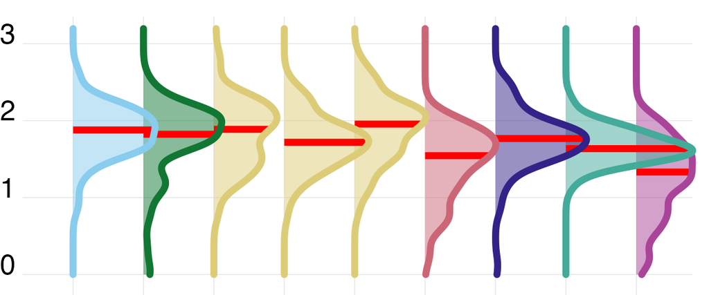

Brightest 10 h mean

lx

**110.6**  
(41.51, 243.2)  
*214.9 ± 508.6*  
N=141; d=816

**252.7**  
(104.5, 462)  
*399.3 ± 518.1*  
N=13; d=78

**176**  
(78.62, 299.1)  
*262.2 ± 329.2*  
N=13; d=78

**156.2**  
(67.78, 339.7)  
*422.5 ± 1,210*  
N=18; d=107

**100.1**  
(33.25, 209.9)  
*179.4 ± 241.5*  
N=26; d=150

**130.8**  
(54.04, 259.7)  
*201.9 ± 194*  
N=10; d=60

**101.1**  
(24.36, 218.5)  
*136.3 ± 134.1*  
N=23; d=129

**83.24**  
(53.17, 151.8)  
*120.2 ± 101.5*  
N=17; d=101

**68.14**  
(45.33, 132.5)  
*96.73 ± 72.31*  
N=6; d=32

**46.66**  
(9.242, 103.2)  
*82.49 ± 115.1*  
N=15; d=81

Log 10 zero inflated

Brightest 10 h mean distribution by site. Exact numerical summaries are in the adjacent cells.

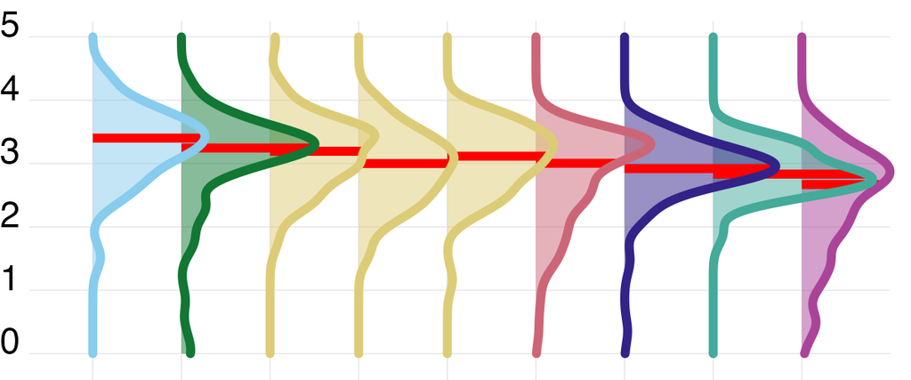

Darkest 10 h mean

lx

**0.1025**  
(0.02012, 0.2534)  
*0.2434 ± 0.5128*  
N=141; d=816

**0.08021**  
(0.01618, 0.1908)  
*0.1832 ± 0.2993*  
N=13; d=78

**0.1001**  
(0.03524, 0.2301)  
*0.2003 ± 0.3323*  
N=13; d=78

**0.1397**  
(0.03643, 0.2822)  
*0.2233 ± 0.2991*  
N=18; d=107

**0.1495**  
(0.07388, 0.3086)  
*0.2733 ± 0.4652*  
N=26; d=150

**0.3254**  
(0.1186, 0.7102)  
*0.5155 ± 0.6529*  
N=10; d=60

**0.02171**  
(0, 0.07961)  
*0.05361 ± 0.07491*  
N=23; d=129

**0.152**  
(0.05193, 0.4814)  
*0.4754 ± 0.8823*  
N=17; d=101

**0.1327**  
(0.05541, 0.3086)  
*0.4113 ± 1.044*  
N=6; d=32

**0.01021**  
(0, 0.09174)  
*0.0591 ± 0.1041*  
N=15; d=81

Log 10 zero inflated

Darkest 10 h mean distribution by site. Exact numerical summaries are in the adjacent cells.

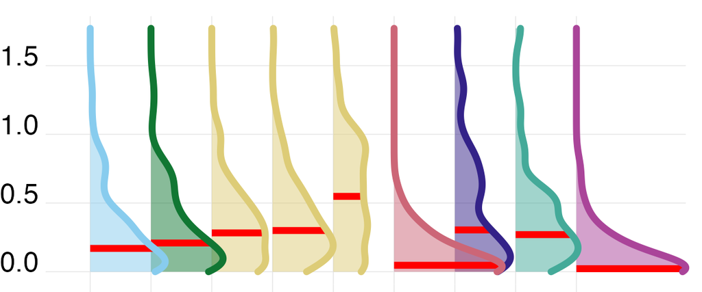

Spectrum

Melanopic daylight efficacy ratio

dimensionless

**0.869**  
(0.798, 0.91)  
*0.844 ± 0.105*  
N=141; d=760

**0.907**  
(0.875, 0.942)  
*0.899 ± 0.0656*  
N=13; d=71

**0.894**  
(0.848, 0.918)  
*0.864 ± 0.146*  
N=13; d=74

**0.89**  
(0.848, 0.927)  
*0.866 ± 0.101*  
N=18; d=97

**0.843**  
(0.756, 0.892)  
*0.812 ± 0.103*  
N=26; d=137

**0.883**  
(0.822, 0.918)  
*0.856 ± 0.0941*  
N=10; d=55

**0.83**  
(0.766, 0.873)  
*0.808 ± 0.0961*  
N=23; d=124

**0.88**  
(0.79, 0.921)  
*0.852 ± 0.108*  
N=17; d=96

**0.844**  
(0.808, 0.911)  
*0.847 ± 0.0629*  
N=6; d=30

**0.853**  
(0.818, 0.883)  
*0.846 ± 0.0891*  
N=15; d=76

Identity

Melanopic daylight efficacy ratio distribution by site. Exact numerical summaries are in the adjacent cells.

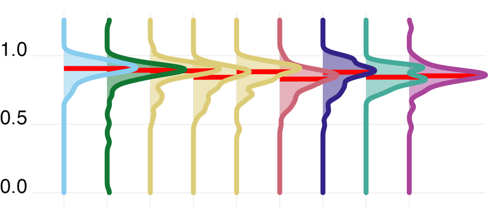

Timing

Midpoint of the brightest 10 hours

HH:MM clock time

**13:44**  
(12:48, 15:00)  
*13:56 ± 01:51*  
N=141; d=816

**13:16**  
(12:28, 14:10)  
*13:20 ± 01:33*  
N=13; d=78

**14:12**  
(13:23, 15:18)  
*14:22 ± 01:51*  
N=13; d=78

**13:52**  
(12:54, 15:04)  
*14:00 ± 01:42*  
N=18; d=107

**13:38**  
(12:47, 14:44)  
*13:52 ± 01:42*  
N=26; d=150

**14:54**  
(12:50, 16:03)  
*14:31 ± 02:14*  
N=10; d=60

**13:44**  
(13:06, 15:20)  
*14:10 ± 01:51*  
N=23; d=129

**14:10**  
(13:32, 15:21)  
*14:25 ± 01:37*  
N=17; d=101

**12:34**  
(11:49, 14:02)  
*12:55 ± 01:44*  
N=6; d=32

**12:49**  
(12:06, 13:39)  
*13:03 ± 01:58*  
N=15; d=81

Circular clock

Midpoint of the brightest 10 hours distribution by site. Exact numerical summaries are in the adjacent cells.

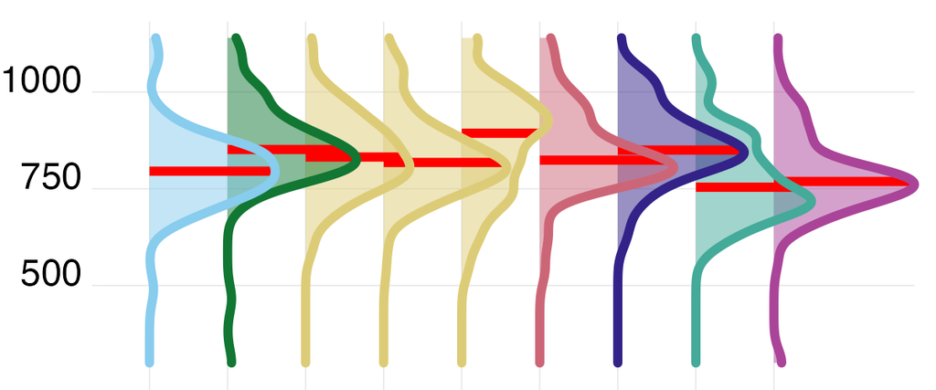

Midpoint of the darkest 10 hours

HH:MM clock time

**02:54**  
(02:01, 03:50)  
*02:58 ± 01:41*  
N=141; d=816

**02:02**  
(01:25, 02:48)  
*02:03 ± 01:07*  
N=13; d=78

**02:55**  
(02:01, 03:27)  
*02:50 ± 02:05*  
N=13; d=78

**02:32**  
(01:45, 03:22)  
*02:37 ± 01:19*  
N=18; d=107

**03:08**  
(02:11, 04:10)  
*03:16 ± 01:34*  
N=26; d=150

**02:37**  
(01:54, 04:17)  
*03:10 ± 02:00*  
N=10; d=60

**03:39**  
(02:43, 04:34)  
*03:34 ± 01:49*  
N=23; d=129

**03:31**  
(02:33, 04:14)  
*03:26 ± 01:25*  
N=17; d=101

**01:45**  
(01:05, 03:01)  
*02:10 ± 01:27*  
N=6; d=32

**02:33**  
(02:04, 03:17)  
*02:36 ± 01:36*  
N=15; d=81

Circular clock

Midpoint of the darkest 10 hours distribution by site. Exact numerical summaries are in the adjacent cells.

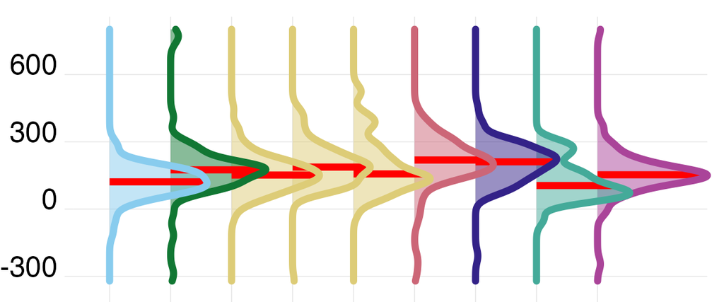

First light timing above 250 lx melEDI

HH:MM clock time

**09:08**  
(08:02, 10:40)  
*09:26 ± 02:22*  
N=140; d=727

**07:57**  
(06:56, 08:33)  
*08:03 ± 01:32*  
N=13; d=74

**09:04**  
(08:18, 09:52)  
*09:17 ± 01:56*  
N=13; d=68

**08:36**  
(07:10, 10:13)  
*08:45 ± 02:21*  
N=18; d=93

**09:43**  
(08:13, 10:53)  
*09:45 ± 02:21*  
N=25; d=133

**09:36**  
(07:58, 10:53)  
*09:39 ± 03:12*  
N=10; d=56

**09:32**  
(08:40, 11:21)  
*10:05 ± 02:18*  
N=23; d=118

**10:01**  
(09:06, 11:52)  
*10:26 ± 02:28*  
N=17; d=95

**08:11**  
(07:26, 09:57)  
*08:36 ± 01:30*  
N=6; d=29

**08:43**  
(08:01, 10:10)  
*09:19 ± 01:52*  
N=15; d=61

Circular clock

First light timing above 250 lx melEDI distribution by site. Exact numerical summaries are in the adjacent cells.

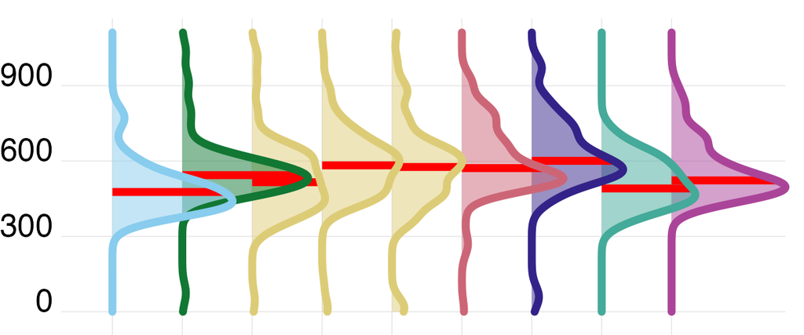

Last light timing above 250 lx melEDI

HH:MM clock time

**18:08**  
(16:27, 19:42)  
*18:03 ± 02:36*  
N=141; d=687

**18:41**  
(17:38, 19:38)  
*18:39 ± 01:38*  
N=13; d=73

**18:30**  
(17:37, 19:59)  
*18:37 ± 02:08*  
N=13; d=62

**19:34**  
(18:04, 20:42)  
*19:16 ± 02:28*  
N=18; d=89

**17:37**  
(15:35, 19:09)  
*17:18 ± 02:44*  
N=26; d=121

**19:50**  
(18:37, 20:50)  
*19:33 ± 02:11*  
N=10; d=53

**17:48**  
(16:46, 19:19)  
*18:01 ± 02:21*  
N=23; d=106

**18:45**  
(17:02, 19:38)  
*18:23 ± 02:15*  
N=17; d=89

**15:45**  
(13:20, 16:38)  
*15:22 ± 02:38*  
N=6; d=28

**15:54**  
(14:34, 17:25)  
*15:46 ± 02:13*  
N=15; d=66

Circular clock

Last light timing above 250 lx melEDI distribution by site. Exact numerical summaries are in the adjacent cells.

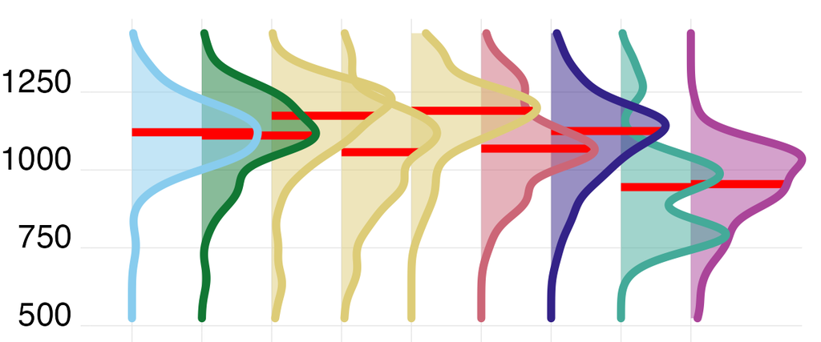

Mean timing of exposure above 250 lx melEDI

HH:MM clock time

**13:29**  
(12:29, 14:39)  
*13:31 ± 01:52*  
N=141; d=742

**13:20**  
(12:29, 14:24)  
*13:21 ± 01:25*  
N=13; d=72

**13:52**  
(13:13, 15:06)  
*14:02 ± 01:41*  
N=13; d=71

**13:44**  
(12:28, 14:55)  
*13:51 ± 01:56*  
N=18; d=93

**13:17**  
(12:17, 14:31)  
*13:24 ± 01:45*  
N=26; d=138

**14:04**  
(12:58, 15:25)  
*14:09 ± 02:22*  
N=10; d=55

**13:43**  
(12:55, 14:29)  
*13:47 ± 01:33*  
N=23; d=117

**13:58**  
(12:54, 14:58)  
*14:04 ± 01:39*  
N=17; d=94

**11:30**  
(10:28, 12:38)  
*11:26 ± 01:36*  
N=6; d=31

**12:17**  
(11:04, 13:04)  
*12:11 ± 01:36*  
N=15; d=71

Circular clock

Mean timing of exposure above 250 lx melEDI distribution by site. Exact numerical summaries are in the adjacent cells.

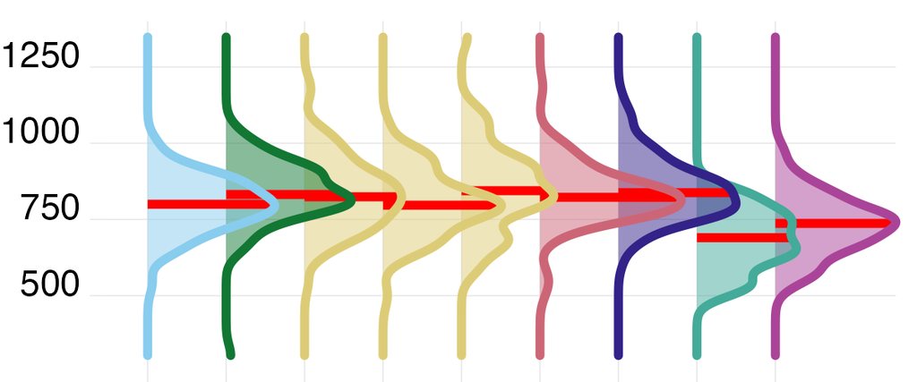

**Median** (25th percentile, 75th percentile), *circular or arithmetic mean ± standard deviation*, N=participants; d=participant-days with a finite value for that metric.

<sup>1</sup> Scaling describes the distribution column only; printed values remain on their stated scale. Log 10 zero inflated uses a base-10 pseudo-log display with a 0.1 offset; Identity is linear; Circular clock unwraps values around the metric-specific clock centre.

<sup>2</sup> Red lines indicate site medians. Pseudo-log and circular-clock rows are transformed only for plotting.

The numerical values in Table 3 come from the approved metric artifacts; the table does not recalculate any metric. Clock-time means and middle-50% intervals are circular, rather than treating 23:59 and 00:01 as far apart. The miniature plots are redundant visual summaries: the adjacent cells remain the authoritative values and provide the exact denominators.

## Figure 1: study overview

The study overview retains the submitted five-part composition: protocol, site map, collection timing, photoperiod coverage, and a repeated 48-hour near-eye profile. The second 24-hour cycle is a display duplicate, not additional data.

[figure not shown]

Figure 1: Study protocol, locations, collection dates, observed civil photoperiod, and the participant-balanced main near-eye 48-hour double profile.

The black profile is the 15-minute median after giving each participant equal influence; the grey ribbon is the pointwise central 90% value interval across participant medians. It is not a confidence interval and does not show an unaggregated one-minute range. The baseline strips show average civil night, average diary sleep, and declared non-wear.

## Figure 2: site-specific profiles

The main near-eye profiles retain the earlier 3 × 3 double-plot layout and registered site order.

[figure not shown]

Figure 2: Participant-balanced main near-eye melEDI profiles by site, with each 24-hour cycle repeated once.

The complementary chest profile uses the same visual grammar. Tübingen is omitted because the updated chest main dataset contains no eligible MPI site panel; the remaining sites retain their registered order and colours.

[figure not shown]

Figure 3: Complementary chest-level melEDI profiles by available site, with each 24-hour cycle repeated once.

Chest values describe the environment at the chest sensor. They are not treated as equivalent to near-eye or ocular exposure.

## Figure 3: reader-facing metric distributions

Figure 4 reproduces the old 4 × 4 ordering and ridge-plus-box construction. Site names remain visible in the first column of panels, so colour is not the only way to identify a distribution.

[figure not shown]

Figure 4: Sixteen familiar near-eye melEDI metric distributions by site.

## Figure 4: from time series to a daily metric

The old explanatory figure used seven fixed German-site examples over Wednesday to Sunday. Figure 5 retains the same IDs and four-panel composition. The source CSV preserves each participant’s actual local date, while the visible x-axis aligns protocol weekdays for comparison.

[figure not shown]

Figure 5: The same seven manuscript examples link verified 30-minute near-eye melEDI series to the approved daily duration above 250 lx during wake.

Panel A uses verified 30-minute arithmetic means. Panels B–D use daily metric values joined from the verified metric artifact; they are not independently recomputed from the plotted bins. This figure illustrates the fixed examples and does not estimate a population weekday effect.

## Figure 5: latitude and observed photoperiod

The latitude diagnostic is retained as supplementary context based on the 816 main near-eye participant-days. Its black impossible-region ribbons consume the verified theoretical bounds from the current H1 reporting artifact, so the panel follows the submitted and current H1 visual grammar without a new calculation in the descriptive pipeline.

[figure not shown]

Figure 6: Observed verified civil photoperiod and verified theoretical bounds by absolute latitude for main near-eye participant-days.

## Light exposure in recommendation contexts

Table 4 preserves the earlier site-row and state-column organization. The thresholds are wake ≥250 lx melEDI, before sleep ≤10 lx melEDI, and sleep ≤1 lx melEDI (Brown et al. 2022). The results are deliberately described as *fractions of valid measured minutes in a recommended range*, not as adherence, compliance, or evidence of a biological response.

Table 4: Fractions of updated main near-eye minutes in the Brown et al. light-context ranges, with explicit denominators.

| Site<sup>1</sup> | Minutes in the recommended range:<sup>2</sup> Wake | Minutes in the recommended range:<sup>2</sup> Pre-sleep | Minutes in the recommended range:<sup>2</sup> Sleep<sup>4</sup> | Minutes in the recommended range:<sup>2</sup> Total<sup>5</sup> | Share of all eligible real minutes:<sup>3</sup> Wake | Share of all eligible real minutes:<sup>3</sup> Pre-sleep | Share of all eligible real minutes:<sup>3</sup> Sleep | Share of all eligible real minutes:<sup>3</sup> Unclassified<sup>6</sup> |
| --- | --- | --- | --- | --- | --- | --- | --- | --- |
| Overall | **24.0%** 137,792573,712 | **63.3%** 81,894129,390 | **87.7%** 336,052383,366 | **51.2%** 555,7381,086,468 | **51.6%** 606,2151,175,160 | **11.9%** 140,1521,175,160 | **32.6%** 383,6071,175,160 | **3.8%** 45,1861,175,160 |
| Borås (SE) | **33.2%** 19,22557,952 | **69.9%** 8,91412,759 | **93.4%** 33,15235,489 | **57.7%** 61,291106,200 | **54.0%** 60,642112,260 | **12.2%** 13,704112,260 | **31.7%** 35,549112,260 | **2.1%** 2,365112,260 |
| Delft (NL) | **29.6%** 14,76049,852 | **66.7%** 7,18110,774 | **86.4%** 29,91534,621 | **54.4%** 51,85695,247 | **47.0%** 52,755112,260 | **10.9%** 12,283112,260 | **30.9%** 34,682112,260 | **11.2%** 12,540112,260 |
| Dortmund (DE) | **32.4%** 22,63169,900 | **59.6%** 9,74916,361 | **87.5%** 42,82948,928 | **55.6%** 75,209135,189 | **48.1%** 74,094154,080 | **11.3%** 17,409154,080 | **31.8%** 48,928154,080 | **8.9%** 13,649154,080 |
| Tübingen (DE) | **22.5%** 25,082111,396 | **61.8%** 15,62325,283 | **87.1%** 61,03070,029 | **49.2%** 101,735206,708 | **55.1%** 119,150216,120 | **12.4%** 26,881216,120 | **32.4%** 70,089216,120 | **0.0%** 0216,120 |
| Munich (DE) | **25.0%** 10,68142,685 | **60.6%** 5,9639,833 | **71.7%** 21,48529,951 | **46.2%** 38,12982,469 | **53.0%** 45,83186,400 | **12.3%** 10,61886,400 | **34.7%** 29,95186,400 | **0.0%** 086,400 |
| Madrid (ES) | **24.2%** 21,06787,030 | **62.7%** 12,76620,366 | **95.9%** 58,37460,891 | **54.8%** 92,207168,287 | **48.4%** 89,948185,880 | **11.7%** 21,684185,880 | **32.8%** 60,891185,880 | **7.2%** 13,357185,880 |
| Izmir (TR) | **17.8%** 12,70871,562 | **55.1%** 9,22116,736 | **79.0%** 39,93650,556 | **44.6%** 61,865138,854 | **51.5%** 74,926145,440 | **12.3%** 17,883145,440 | **34.8%** 50,556145,440 | **1.4%** 2,075145,440 |
| San José (CR) | **13.8%** 3,26623,640 | **64.6%** 3,1244,839 | **87.1%** 12,43814,275 | **44.0%** 18,82842,754 | **54.9%** 25,28546,080 | **11.5%** 5,32046,080 | **31.0%** 14,27546,080 | **2.6%** 1,20046,080 |
| Kumasi (GH) | **14.0%** 8,37259,695 | **75.2%** 9,35312,439 | **95.5%** 36,89338,626 | **49.3%** 54,618110,760 | **54.5%** 63,584116,640 | **12.3%** 14,370116,640 | **33.2%** 38,686116,640 | **0.0%** 0116,640 |

<sup>1</sup> Near-eye participant and participant-day sample sizes are reported in the participant table; every percentage cell gives its exact minute denominator.  
<sup>2</sup> Recommended thresholds follow Brown et al. (2022): wake ≥250 lx melEDI, pre-sleep ≤10 lx melEDI, and sleep ≤1 lx melEDI. These are measured environmental contexts, not adherence or compliance. Each small fraction gives minutes within the recommended context over all valid one-minute observations in that context.  
<sup>3</sup> Each small fraction gives minutes in the displayed diary state over all eligible real minutes before classification by diary state or measurement availability.  
<sup>4</sup> During diary-defined sleep the bedside sensor describes the sleep environment rather than direct ocular exposure.  
<sup>5</sup> Total pools all classified valid minutes.  
<sup>6</sup> Unclassified time can result from missing diary state, missing or removed melEDI measurements, or both.

Each percentage is followed by a compact two-line numerator/denominator fraction. Wake, before-sleep, and sleep cells divide minutes within the recommended context by all valid one-minute observations in that diary state; the combined column pools all classified valid minutes. The four state-share columns divide minutes in the displayed state by all eligible real minutes. Diary-defined sleep combines the near-eye sensor while awake with a bedside sensor during sleep; the sleep row therefore describes the sleep environment rather than direct ocular exposure.

## Exact comparison with the earlier render

The earlier HTML was read only as a record of displayed cells; no old `.RData` workspace was loaded. Machine-readable comparisons cover every displayed publication-table cell:

Table 5: Complete cell-level comparison with the earlier manuscript-generating tables.

| Table | Comparison status | Cells |
| --- | --- | --- |
| participant | ADDED | 70 |
| participant | DISPLAY_CHANGED | 114 |
| participant | DISPLAY_UNCHANGED | 36 |
| metric | DISPLAY_CHANGED | 170 |
| recommendation | DISPLAY_CHANGED | 42 |
| recommendation | DISPLAY_UNCHANGED | 38 |

The comparison summary above reports all current cells and classifies each against the submitted render. Metric timing rows also changed to circular summaries, while the contextual table reflects the updated eligible-day and state denominators.

Every numerical cell, plus the explanation assigned to its difference, is in:

- `audit/descriptives/previous_table1_comparison.csv`
- `audit/descriptives/previous_table2_comparison.csv`
- `audit/descriptives/previous_recommendation_comparison.csv`

Every old table, figure, panel, and batch export is covered by `audit/descriptives/output_difference_explanations.csv`. Redundant reduced tables, letter-only metric exports, and individual site PDFs were not copied as separate deliverables because they add no distinct construct; their values and panels remain in the full replicated tables, composite figures, and exact source CSVs.

### Stand-alone visual exports

The three publication tables are exported as PNG files with the original `gtsave()` viewport widths. Each of the six durable figures is exported at the V0 manuscript canvas as a 300-dpi PNG, a maximum-quality JPEG, a one-page PDF, and an SVG. Figure 1 uses the nominal 10.5 × 10 inch V0 canvas rather than the old file’s additional 1.5 export multiplier, which had made the composite and its embedded text too large in the report. The following record gives the retained original and rebuilt PNG paths, dimensions, and hashes needed for direct side-by-side review:

Table 6: Original and rebuilt visual exports available for side-by-side comparison.

| Output | Type | Original | Rebuilt | Original pixels | Rebuilt pixels |
| --- | --- | --- | --- | --- | --- |
| participant_site_characteristics | table | tables/tbl1.png | artifacts/09_tables/descriptives/participant_site_characteristics_replica.png | 2358 × 3256 | 2388 × 2922 |
| near_eye_metric_summary | table | tables/tbl2.png | artifacts/09_tables/descriptives/metric_descriptive_summary_replica.png | 3420 × 4182 | 3494 × 4996 |
| recommendation_context | table | tables/Brown_table.png | artifacts/09_tables/descriptives/recommendation_context_replica.png | 1972 × 1070 | 1972 × 1792 |
| descriptive_overview | figure | figures/Fig1.png | artifacts/10_figures/descriptives/descriptive_overview.png | 4725 × 4500 | 3150 × 3000 |
| near_eye_site_profiles | figure | figures/Fig2.png | artifacts/10_figures/descriptives/near_eye_site_profiles.png | 5400 × 3600 | 5400 × 3600 |
| chest_site_profiles | figure | figures/Fig2.png | artifacts/10_figures/descriptives/chest_site_profiles.png | 5400 × 3600 | 5400 × 3600 |
| near_eye_metric_distributions | figure | figures/Fig3.png | artifacts/10_figures/descriptives/near_eye_metric_distributions.png | 6000 × 6000 | 6000 × 6000 |
| time_series_to_metrics | figure | figures/Timeseries_to_metrics.png | artifacts/10_figures/descriptives/time_series_to_metrics.png | 3000 × 2700 | 3000 × 2700 |
| latitude_photoperiod_diagnostic | figure | figures/photoperiod_potential_ridges.png | artifacts/10_figures/descriptives/latitude_photoperiod_diagnostic.png | 1800 × 1800 | 1800 × 1800 |

The completed visual assessment, including intended visible differences, is recorded in `audit/descriptives/visual_export_review.md`.

## Reproducibility and output contract

Each durable figure has a fixed filename and dimensions, 300-dpi PNG and JPEG exports, a deterministic one-page PDF, an SVG vector master, accurate alt text, and an exact source-data mapping with source SHA-256 values. The PDF places the verified 300-dpi PNG on a page of the same physical dimensions so that Unicode labels and the inspected layout are preserved exactly while the file remains byte-reproducible. The complete output manifest is `artifacts/12_manifests/descriptives/descriptive_artifacts.csv`; figure-to-source mapping is `artifacts/12_manifests/descriptives/figure_source_data_map.csv`. The DISPLAY-001 registry provenance, including its hash, is recorded in `audit/descriptives/site_display_registry_provenance.csv`.

The three table PNG export settings are recorded in `artifacts/12_manifests/descriptives/table_export_specifications.csv`.

Table 7: Deterministic dimensions and formats for the replicated descriptive figures.

| Figure | Width (in) | Height (in) | DPI | Placement |
| --- | --- | --- | --- | --- |
| descriptive_overview | 10.5 | 10 | 300 | near_eye_primary_and_chest_complementary |
| near_eye_site_profiles | 18.0 | 12 | 300 | near_eye |
| chest_site_profiles | 18.0 | 12 | 300 | chest |
| near_eye_metric_distributions | 20.0 | 20 | 300 | near_eye |
| time_series_to_metrics | 10.0 | 9 | 300 | near_eye |
| latitude_photoperiod_diagnostic | 6.0 | 6 | 300 | near_eye |

The complete descriptive build is run with:

```
RENV_CONFIG_SANDBOX_ENABLED=FALSE Rscript scripts/descriptives/run_descriptives.R
```

This document alone is rendered with:

```
quarto render notebooks/descriptives.qmd --profile nathealth
```

No hypothesis model, inferential p-value, or exploratory H03/H04 analysis is created or duplicated here.

## References

Brown, Timothy M., George C. Brainard, Christian Cajochen, et al. 2022. “Recommendations for Daytime, Evening, and Nighttime Indoor Light Exposure to Best Support Physiology, Sleep, and Wakefulness in Healthy Adults.” *PLOS Biology* 20 (3): e3001571. https://doi.org/10.1371/journal.pbio.3001571.